# Introduction of Facebook Prophet

author : khlee

create date : 14 march, 2017 / revised date : 09 January, 2019

# 1 Overview of Prophet : forecasting at scale

최근 Facebook에서는 R 및 Python을 통해 전문적인 지식 없이 시계열 예측을 쉽게 수행할 수 있는 오픈소스 패키지인 Prophet을 릴리즈하였다. Prophet의 예측은 자동적인 시계열 예측과 시각화를 통해 피드백을 받고 분석가가 피드백에대한 조정을 수행하는 Analyst in the loop 방식이다.

Prophet은 3가지 시계열 모델(growth, seasonality, holidays)로 다음 식과 같이 표현할 수 있다.
$$\large\begin{aligned}
y(t) = g(t) + s(t) + h(t) + {\varepsilon _t}
\end{aligned}$$
g(t)는 growth를 의미하고, s(t)는 seasonality를 의미한다. 그리고 h(t)는 holidays의 영향을 의미한다. epsilon t는 관측할 수 없는 외부 요소의 에러를 나타내고, 정규분포를 따른다. Prophet의 내부적으로는 시계열 예측의 대표적인 방식인 ARIMA가 아닌 Bayesian 방식의 GAM(Generalized Additive Model)인 regression 계열의 방식으로 작동한다.

Prophet은 페이스북에서 자신들의 business에 잘 맞게 최적화 하였기 때문에, 모든 시계열 예측에서 잘 작동한다는 것을 의미하지는 않는다. 구체적으로 다음과 같은 상황의 business에서 잘 작동한다.

- 몇 달이상의(권장 1년) 시간별, 일별, 주별 시계열 데이터
- 요일 및 시간에 따른 계정성이 있는 데이터
- 사전에 알려져 있는 불규칙한 간격에서 발생하는 중요한 공휴일 (예: 명절)
- 어느 정도 누락된 데이터 및 이상치 데이터를 허용할 수 있음
- 제품 출시 또는 로깅 변경으로 인한 추세가 변할 수 있는 데이터
- 트렌드가 자연적 한계에 도달 하거나 비선형적으로 성장하는 곡선

Prophet의 작동 기반인 additive regression model에는 다음과 같은 특징이 있다.

- 구간별 선형 또는 로지스틱 성장 추세에서 데이터의 변경점을 선택하여 초세의 변화를 자동으로 감지
- 연단위의 계절적인 요소는 퓨리에 급수를 사용하여 모델링함
- 주단위의 계적적인 요소는 더미 변수를 사용하여 모델링함
- 중요한 날(추석, 상품 출시, 광고 출시 등)을 요인으로 모델링에 적용할 수 있음

**참조**  
tutorial 원본 https://facebookincubator.github.io/prophet/docs/quick_start.html#r-api read the paper https://facebookincubator.github.io/prophet/static/prophet_paper_20170113.pdf

# 2 quick start of prophet

import library

`r`r library(prophet) library(dplyr) library(ggplot2)

### 2.0.1 read exam data

peyton maning(미식축구선수)의 2007년12월10일 부터 2016년1월20일까지의 위키피디아 방문자 수 데이터이다. 방문자 수 스케일 차이가 크므로 방문자 수의 log scale를 취한다. 데이터의 구조는 ds : 시간과 y: 값을 가진 data frame 형태이다.

`r`r df1 <- read.csv(‘example_wp_peyton_manning.csv’) df1 <- df1 %>% mutate(y = log(y)) head(df1)

|  | ds | y |
| --- | --- | --- |
| 1 | 2007-12-10 | 9.590761 |
| 2 | 2007-12-11 | 8.519590 |
| 3 | 2007-12-12 | 8.183677 |
| 4 | 2007-12-13 | 8.072467 |
| 5 | 2007-12-14 | 7.893572 |
| 6 | 2007-12-15 | 7.783641 |

### 2.0.2 trainning prophet

위 예제와 같은 data frame을 prophet 함수에 넣으므로써 시계열 데이터의 학습을 간단하게 할 수 있다.

`r`r m <- prophet(df1)

[output not shown]

### 2.0.3 predict future

1. make_future_datafame 함수를 사용해서 다음 과 같이 예측할 앞 날의 periods를 입력하여 forecasting data frame을 만든다.  
   default 값은 day이다. 데이터 주기가 week 또는 month이면 by=“week” or by=“month” 를 입력하면 된다.  
   (prophet 모델을 생성할때 data frame의 date 주기와 동일하게 설정한는 것이 좋다)
2. predict 함수를 사용해서 위에서 만든 prophet 모델과 forecasting data frame을 입력하여 예측을 수행한다.

`r`r future <- make_future_dataframe(m, periods = 365) forecast <- predict(m, future)

### 2.0.4 plotting the forecast

예측된 forecast data frame에는 예측값 및 upper, lower 등 다양한 예측 구성요소의 필드를 가진다.

`r`r tail(forecast)

|  | ds | t | trend | yhat_lower | yhat_upper | trend_lower | trend_upper | seasonal_lower | seasonal_upper | weekly | weekly_lower | weekly_upper | yearly | yearly_lower | yearly_upper | seasonal | yhat |
| --- | --- | --- | --- | --- | --- | --- | --- | --- | --- | --- | --- | --- | --- | --- | --- | --- | --- |
| 3264 | 2017-01-13 | 1.121161 | 7.198286 | 7.345121 | 8.847836 | 6.861400 | 7.596168 | 0.8537681 | 0.8537681 | -0.06957521 | -0.06957521 | -0.06957521 | 0.9233434 | 0.9233434 | 0.9233434 | 0.8537681 | 8.052054 |
| 3265 | 2017-01-14 | 1.121498 | 7.197270 | 7.113265 | 8.630767 | 6.858948 | 7.596919 | 0.6351261 | 0.6351261 | -0.31170257 | -0.31170257 | -0.31170257 | 0.9468286 | 0.9468286 | 0.9468286 | 0.6351261 | 7.832396 |
| 3266 | 2017-01-15 | 1.121836 | 7.196254 | 7.531054 | 9.026211 | 6.856589 | 7.598450 | 1.0179787 | 1.0179787 | 0.04831898 | 0.04831898 | 0.04831898 | 0.9696597 | 0.9696597 | 0.9696597 | 1.0179787 | 8.214232 |
| 3267 | 2017-01-16 | 1.122173 | 7.195238 | 7.799939 | 9.311485 | 6.853811 | 7.599308 | 1.3440019 | 1.3440019 | 0.35228965 | 0.35228965 | 0.35228965 | 0.9917122 | 0.9917122 | 0.9917122 | 1.3440019 | 8.539239 |
| 3268 | 2017-01-17 | 1.122511 | 7.194222 | 7.640736 | 9.077957 | 6.850784 | 7.598396 | 1.1324326 | 1.1324326 | 0.11960901 | 0.11960901 | 0.11960901 | 1.0128236 | 1.0128236 | 1.0128236 | 1.1324326 | 8.326654 |
| 3269 | 2017-01-18 | 1.122848 | 7.193206 | 7.413258 | 8.841059 | 6.848361 | 7.597483 | 0.9661309 | 0.9661309 | -0.06665948 | -0.06665948 | -0.06665948 | 1.0327904 | 1.0327904 | 1.0327904 | 0.9661309 | 8.159337 |

plot함수에 prophet 모델과 forecast 값을 입력하면 검은 점 실제 값과 파란색 라인의 예측 값으로 ploting 된다.

`r`r plot(m, forecast)

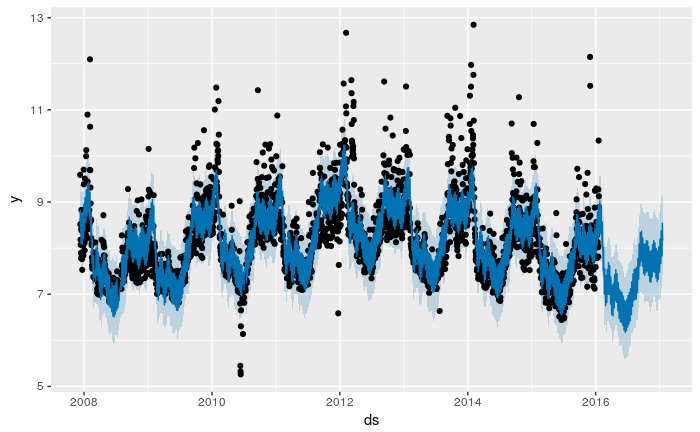

prophet_plot_components 함수를 사용해서 그 외에 prophet의 trend, weekly, yearly의 구성요소를 그래프로 확인 할 수 있다.  
*그래프 해석*  
trend는 2016년 이후 감소하는 추세를 보이고 뒤로 갈 수 록 불확실성(uncertainty)이 커지는 것을 볼 수 있다.  
weekly는 일요일에 증가해서 월요일에 피크를 찍고 감소하는 것으로 보인다. yearly는 9월 이후 부터 년 초까지 높은 값을 유지하고 3월 이후 부터 떨어지는 것으로 미식축구의 시즌성을 보여준다.

`r`r prophet_plot_components(m, forecast)

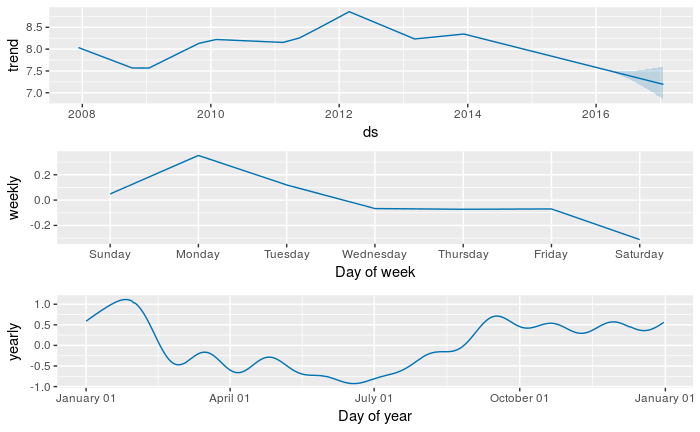

# 3 forecasting growth

### 3.0.1 read exam data

forecasting growth의 예제 데이터는 2008년1월30일 부터 2015년12월19일 까지 위키피디아 R (programming language)페이지의 방문자 수이다.  
방수자 수에 log scale을 취한다.

`r`r df2 <- read.csv(‘example_wp_R.csv’) df2$y <- log(df2$y) head(df2)

|  | ds | y |
| --- | --- | --- |
| 1 | 2008-01-30 | 5.976351 |
| 2 | 2008-01-16 | 6.049733 |
| 3 | 2008-01-17 | 6.011267 |
| 4 | 2008-01-14 | 5.953243 |
| 5 | 2008-01-15 | 5.910797 |
| 6 | 2008-01-12 | 5.407172 |

### 3.0.2 set of carrying capacity and trainning

1. carring capacity를 설정한다.  
   carring capacity는 최대 도달 할 수 있는 성장량을 의미한다. 즉, 총 시장의 크기 및 인구의 크기 등  
   carring capacity는 상수가 될 수 있고 상황에 따라 수용량이 변할 수 있는 함수일 수 있다.
2. prophet 함수에 capacity가 입력된 data frame과 growth=’logistic’을 입력하여 로지스틱 성장 곡선을 예측 할 수 있다.

`r`r df2$cap <- 8.5 m <- prophet(df2, growth = ‘logistic’)

[output not shown]

### 3.0.3 predict future

`r`r future <- make_future_dataframe(m, periods = 1826) future$cap <- 8.5 fcst <- predict(m, future)

### 3.0.4 plotting the forecast

여러 구성요소를 가진 예측 값을 확인 할 수 있다.

`r`r tail(fcst)

|  | ds | cap | t | cap_scaled | trend | yhat_lower | yhat_upper | trend_lower | trend_upper | seasonal_lower | seasonal_upper | weekly | weekly_lower | weekly_upper | yearly | yearly_lower | yearly_upper | seasonal | yhat |
| --- | --- | --- | --- | --- | --- | --- | --- | --- | --- | --- | --- | --- | --- | --- | --- | --- | --- | --- | --- |
| 4683 | 2020-12-24 | 8.5 | 1.623074 | 0.9384448 | 8.201701 | 7.738521 | 8.340100 | 8.181781 | 8.223655 | -0.1626894 | -0.1626894 | 0.14870997 | 0.14870997 | 0.14870997 | -0.3113994 | -0.3113994 | -0.3113994 | -0.1626894 | 8.039011 |
| 4684 | 2020-12-25 | 8.5 | 1.623417 | 0.9384448 | 8.201830 | 7.640979 | 8.225885 | 8.181904 | 8.223806 | -0.2642518 | -0.2642518 | 0.05146728 | 0.05146728 | 0.05146728 | -0.3157191 | -0.3157191 | -0.3157191 | -0.2642518 | 7.937578 |
| 4685 | 2020-12-26 | 8.5 | 1.623759 | 0.9384448 | 8.201959 | 7.270285 | 7.865684 | 8.182028 | 8.223957 | -0.6352549 | -0.6352549 | -0.31902149 | -0.31902149 | -0.31902149 | -0.3162334 | -0.3162334 | -0.3162334 | -0.6352549 | 7.566704 |
| 4686 | 2020-12-27 | 8.5 | 1.624101 | 0.9384448 | 8.202088 | 7.262971 | 7.884142 | 8.182151 | 8.224108 | -0.6262099 | -0.6262099 | -0.31337417 | -0.31337417 | -0.31337417 | -0.3128357 | -0.3128357 | -0.3128357 | -0.6262099 | 7.575878 |
| 4687 | 2020-12-28 | 8.5 | 1.624444 | 0.9384448 | 8.202217 | 7.684096 | 8.279031 | 8.182274 | 8.224259 | -0.2056412 | -0.2056412 | 0.09984771 | 0.09984771 | 0.09984771 | -0.3054889 | -0.3054889 | -0.3054889 | -0.2056412 | 7.996576 |
| 4688 | 2020-12-29 | 8.5 | 1.624786 | 0.9384448 | 8.202346 | 7.775394 | 8.378233 | 8.182397 | 8.224399 | -0.1305882 | -0.1305882 | 0.16363909 | 0.16363909 | 0.16363909 | -0.2942273 | -0.2942273 | -0.2942273 | -0.1305882 | 8.071758 |

예측 값을 기존데이터와 함께 plotting한다. 결과 그래프로 설정한 capacity까지 logistic 성장하는 모형을 볼 수 있다.

`r`r plot(m, fcst)

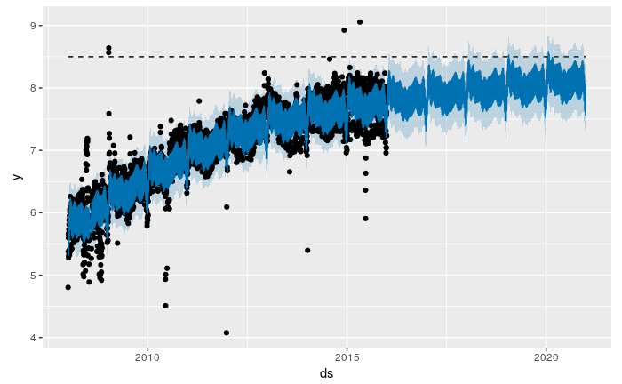

# 4 trend changepoints

### 4.0.1 Automatic changepoint detection in Prophet

실제 대부분의 시계열 데이터는 외부 또는 내부 요인으로 인한 변화가 발생한다.  
prophet은 자동적으로 시계열 데이터의 앞 80% 지점까지 uniform하게 default 25개의 changepoints를 탐지한다.  
quick start에서 사용한 peyton manning wiki trend data를 사용해서 확인해본다.

`r`r m$n.changepoints

```
[1] 25
```

`r`r m$changepoints

```
 [1] \2008-03-17\ \2008-06-20\ \2008-10-11\ \2009-01-14\ \2009-04-17\ \2009-07-19\ \2009-10-26\ \2010-01-31\ \2010-05-06\ \2010-08-14\ \2010-11-15\ \2011-02-16\
[13] \2011-05-20\ \2011-08-21\ \2011-11-24\ \2012-02-27\ \2012-05-31\ \2012-09-01\ \2012-12-02\ \2013-03-05\ \2013-06-06\ \2013-09-08\ \2013-12-10\ \2014-03-14\
[25] \2014-06-15\
```

changepoins를 시계열 plot에 도식하면 다음과 같다.

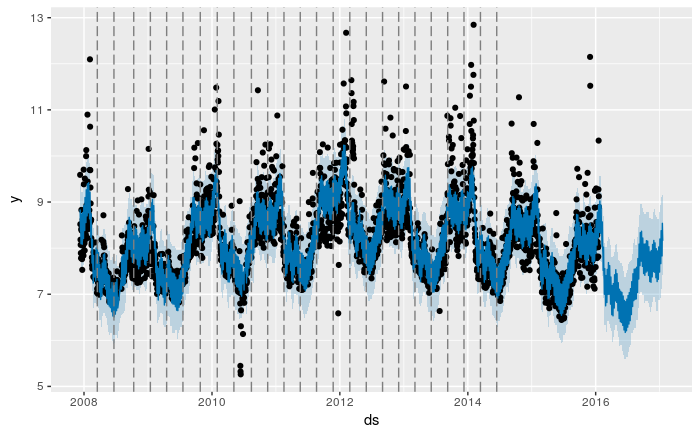

prophet 함수안에 n_changepoints 옵션을 입력하여 changepoints를 선택할 수 있다.

### 4.0.2 Adjusting trend flexibility

trend 변화의 flexibility를 조정할 수 있다. flexibility가 너무 높다는 것은 overfitting을 의미하고 너무 낮다는 것은 underfitting을 의미한다.  
prophet 함수의 changepoint_prior_scale argument의 값을 입력할 수 있다. default 값은 0.05이다.

flexibility를 높여 overfitting을 만들어 보자.  
결고 그래프에서 예측값의 upper bound와 lower bound 값이 점점 벌어지는 것을 확인 할 수 있다. overfitting이 되었기 때문에 시간이 지남에 따라  
불확실성이 높이지기 때문이다.

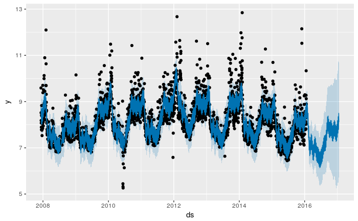

flexibility를 낮춰 underfitting을 만들어 보자.  
결과 그래프에서 예측값은 년도를 주기로 거의 변화가 없는 것으로 나타난다.

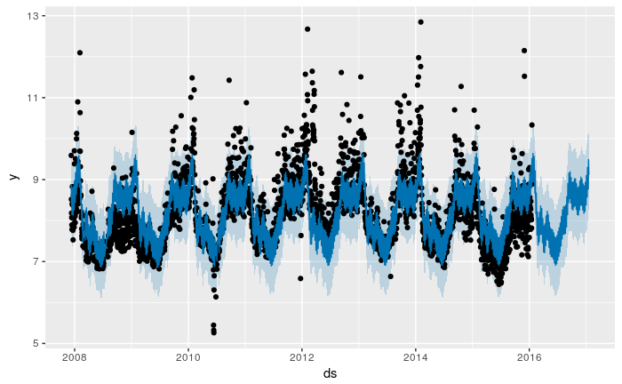

### 4.0.3 Specifying the locations of the changepoints

changepoints를 분석가가 직접 입력할 수 있다. 아래 예제에서 하나의 changepoint를 입력한다.

`r`r m$changepoints

```
[1] \2014-01-01\
```

`r`r forecast <- predict(m, future) plot(m, forecast)

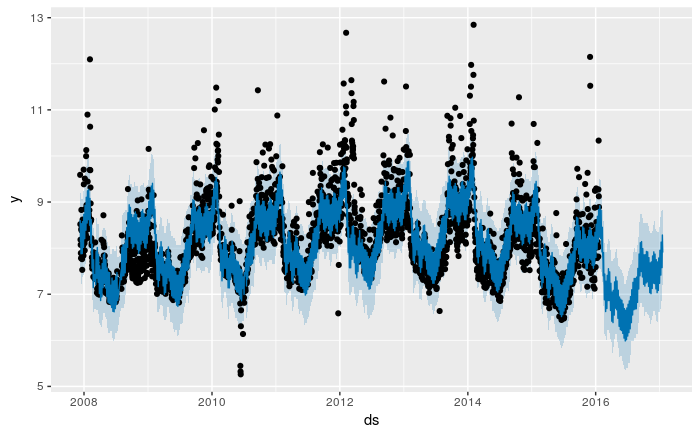

# 5 holiday Effects

### 5.0.1 make sample holiday data frame

playoffs와 superbowls 일정을 event holiday data frame을 만든다. lower_window와 upper_window의 설정은 holiday를 기준으로 전날의 영향을 받는지 다음날의 영향을 받는지를 설정하는 것이다.  
예를 들어 크리스마스는 lower_window 전날인 이브에 영향을 받을 것이고, 슈퍼볼은 게임이 끝난 직후 영향을 미칠 것으로 보인다.

`r`r playoffs <- data_frame( holiday = ‘playoff’, ds = as.Date(c(‘2008-01-13’, ‘2009-01-03’, ‘2010-01-16’, ‘2010-01-24’, ‘2010-02-07’, ‘2011-01-08’, ‘2013-01-12’, ‘2014-01-12’, ‘2014-01-19’, ‘2014-02-02’, ‘2015-01-11’, ‘2016-01-17’, ‘2016-01-24’, ‘2016-02-07’)), lower_window = 0, upper_window = 1 ) superbowls <- data_frame( holiday = ‘superbowl’, ds = as.Date(c(‘2010-02-07’, ‘2014-02-02’, ‘2016-02-07’)), lower_window = 0, upper_window = 1 ) holidays <- bind_rows(playoffs, superbowls) holidays

| holiday | ds | lower_window | upper_window |
| --- | --- | --- | --- |
| playoff | 2008-01-13 | 0 | 1 |
| playoff | 2009-01-03 | 0 | 1 |
| playoff | 2010-01-16 | 0 | 1 |
| playoff | 2010-01-24 | 0 | 1 |
| playoff | 2010-02-07 | 0 | 1 |
| playoff | 2011-01-08 | 0 | 1 |
| playoff | 2013-01-12 | 0 | 1 |
| playoff | 2014-01-12 | 0 | 1 |
| playoff | 2014-01-19 | 0 | 1 |
| playoff | 2014-02-02 | 0 | 1 |

[output cut: 7 more lines]

### 5.0.2 forecasting the time series with holiday

holiday에 대한 요소는 다음 그래프로 확인 할 수 있다. 결과 그래프로 playoff와 superbowl이 동시에 발생한 일에 영향이 높은 것으로 볼 수 있다. (playoff가 뭔지 정확이 모르겠음. superbowl을 미식축구 결승전 한국시리즈와 같아 보이는데 playoff와 superbowl일정이 같다는 것은 무엇을 의미하는지???)

`r`r prophet_plot_components(m, forecast)

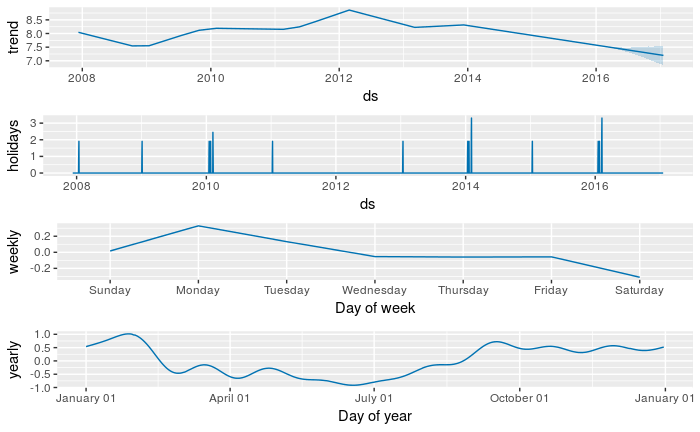

### 5.0.3 Prior scale for holidays and seasonality

*참고*  
시즌성이 있는 prophet 모델에서 holiday와 유사하게 seasonality_prior_scale argument 값으로 조정할 수 있다.

# 6 uncertainty intervals

prophet에서는 기본적으로 80%의 uncertainty intervals (불확실성 구간, 일반적으로 통계에서 말하는 confidence interval과 같은것으로 보인다.)  
로 yhat의 upper와 lower bound 값을 결과로 보여준다.  
interval.width argument로 값을 변경 할 수 있다. 아래 예제에서는 95% 값으로 설정하였다.  
결과 그래프로 uncertainty 값이 높아짐에 따라 하늘색 구간이 커진것으로 볼 수 있다.

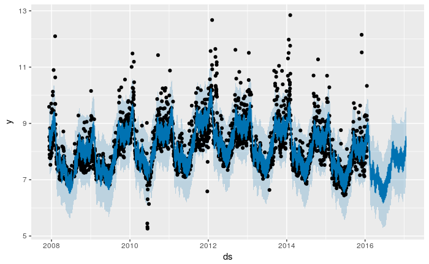

# 7 outliers

기존 시계열 데이터의 예측 모델링에서 null 구간 (이빨빠진 구간) 및 outlier의 처리에 대한 이슈가 있다.  
prophet은 이러한 null구간(resonable한 null 구간)에 대한 자동적으로 예측을 수행한 모델링을 한다.  
또한, outlier에 대해 null 처리를 함으로써 outlier 처리를 쉽게 할수 있다.

### 7.0.1 outlier 1

아래 데이터는 위 예제의 r wiki page trend 데이터에서 2010년을 outlier 처리한 것이다.  
예측 결과 그래프를 보면, outlier 때문에 예측 값이 uncertainty가 매우 커지는 것으로, outlier가 예측에 나쁜 영향을 미친것으로 볼 수 있다.

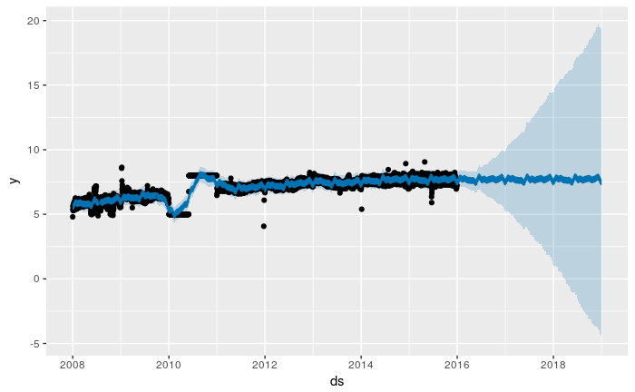

outlier를 null 값처리해서 예측을 수행한다.  
결과 그래프에서 outlier를 처리 하지 않았을 때보다 안정적인 그래프 모양을 따른다.

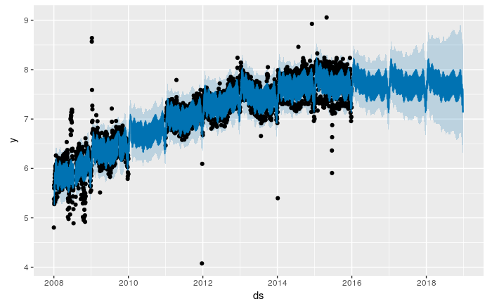

### 7.0.2 outlier 2

이번에 2015년6월의 값을 아웃라이어로 낮게 설정한 데이터이다.  
결과 그래프를 보면 outlier의 영향을 받아 2016년 이후 예측 값이 잘 피팅이 되지 않는 것을 볼 수 있다.

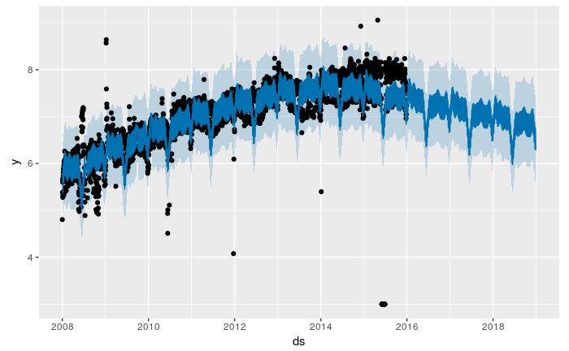

outlier 구간을 null처리하여 예측을 수행한다.  
예측이 뒤로 갈 수 록 uncertainty값이 커지지만, outlier를 제거하지 않을때보다 안정적으로 예측된 것을 볼 수 있다.

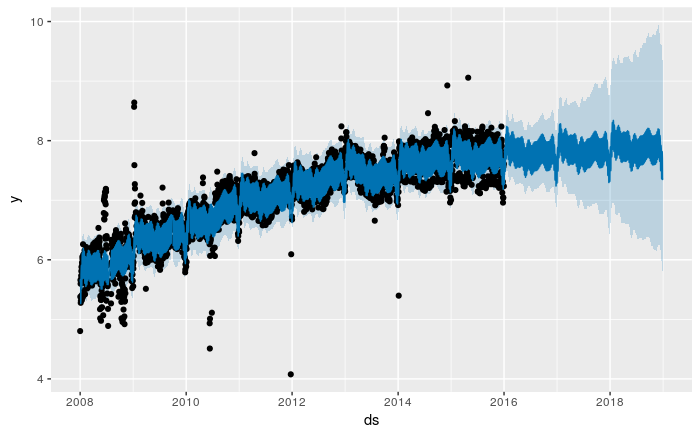

# 8 non-daily data

위 예제는 daily 시계열 데이터에 대한 예측을 수행하였다. prophet은 daily뿐 아니라 weekly, monthly, quarterly 수행이 가능하다.  
이번 예제에서는 US retail sales volume인 monthly 데이터를 사용하여 next 10 years forecasting을 수행해본다.

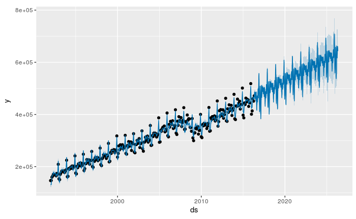

위 결과 그래프의 예측부분이 history 데이터와 달라보이는데, input data의 date 구간에 따라 future data의 date 구간을 맞춰야 한다.  
make_future_dataframe 함수에서 freq=‘m’ 값을 입력하여 monthly data임을 명시하고 forecasting을 수행한다.

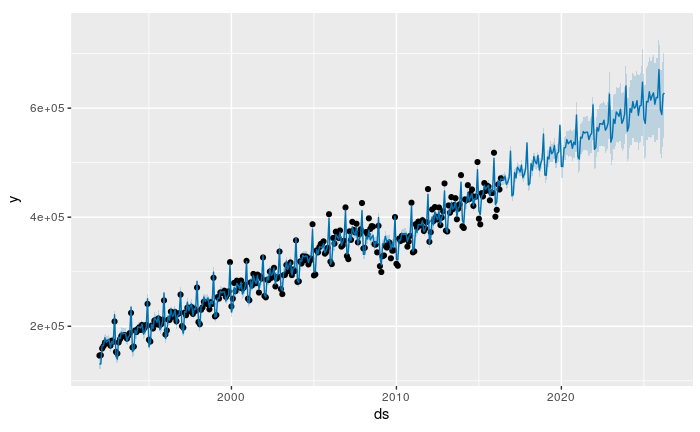